# Sample Clustering: PCA

Carlota Myhre de Gouveia

2026-10-04

# Introduction

Principal Component Analysis (PCA) is used here as an exploratory tool to visualize overall patterns of gene expression across samples. By reducing the high-dimensional transcriptome data into a small number of principal components, PCA highlights the major sources of variation in the dataset. This allows us to assess whether samples cluster according to biological factors such as origin (South, West, Hybrid) or temperature treatment (12°C, 15°C, 18°C), and to identify potential outliers before performing differential expression analysis.

## Setup and load required libraries

```r
# Load libraries
suppressPackageStartupMessages({
  library(DESeq2)
  library(ggplot2)
  library(dplyr)
  library(ggrepel)
    library(readxl)
})
```

## Data Import and Preprocessing

```r
# Load transcript abundance matrix
abundance_matrix <- read.table(
  "data/DE/abundance_matrix.txt",
  header = TRUE, row.names = 1, check.names = FALSE
)

# Clean column names
colnames(abundance_matrix) <- sub(".*Melops", "", colnames(abundance_matrix))

# Load metadata and recode origin
sample_info <- read_excel("data/sample_conditions_rnaseq.xlsx") %>%
  mutate(
    sample = sub("L", "", RNA_Later_ID),   # matches abundance matrix columns
    origin = recode(Origin,
      "W" = "West",
      "H" = "Hybrid",
      "S" = "South"
    ),
    origin = factor(origin, levels = c("Hybrid", "South", "West")),
    temperature = factor(`Temperature (celsius)`, levels = c(12,15,18)),
    condition = factor(RNAseqgroup,
                       levels = c("W12","W15","W18",
                                  "H12","H15","H18",
                                  "S12","S15","S18")),
    length = `Total length (mm)`,
    weight = `Weight (g)`,
    condition_factor = 100 * (weight / (length/10)^3)  # convert mm→cm
  ) %>%
  select(sample, origin, temperature, condition,
         length, weight, condition_factor) %>%
  arrange(match(sample, colnames(abundance_matrix)))

# Show preview of the abundance matrix
knitr::kable(abundance_matrix[1:10, 1:10],
             caption = "Gene abundance matrix (first 10 genes × 10 samples)")
```

Gene abundance matrix (first 10 genes × 10 samples)

|  | 1040 | 1037 | 1036 | 1035 | 1033 | 1025 | 1024 | 1023 | 1022 | 1021 |
| --- | --- | --- | --- | --- | --- | --- | --- | --- | --- | --- |
| TRINITY_GG_716_c838_g1 | 0.00 | 2.00 | 0.00 | 0.00 | 0.00 | 0.00 | 0.00 | 0.00 | 0.00 | 0.00 |
| TRINITY_GG_1114_c422_g3 | 0.00 | 0.00 | 0.00 | 0.00 | 0.00 | 0.00 | 0.00 | 0.00 | 0.00 | 0.00 |
| TRINITY_GG_1463_c526_g6 | 0.00 | 7.00 | 0.00 | 3.00 | 0.00 | 0.00 | 1.00 | 0.00 | 2.00 | 1.00 |
| TRINITY_GG_1586_c745_g1 | 0.00 | 0.00 | 0.00 | 0.00 | 0.00 | 0.00 | 0.00 | 0.00 | 0.00 | 0.00 |
| TRINITY_GG_560_c228_g1 | 1.00 | 2.00 | 1.00 | 0.00 | 0.00 | 0.00 | 0.00 | 0.00 | 0.00 | 0.00 |
| TRINITY_GG_606_c418_g2 | 1.00 | 1.00 | 1.00 | 1.00 | 3.00 | 6.00 | 5.00 | 0.00 | 2.00 | 2.00 |
| TRINITY_GG_1604_c217_g2 | 0.91 | 2.81 | 0.00 | 0.00 | 1.63 | 2.00 | 3.00 | 0.00 | 0.00 | 0.00 |
| TRINITY_GG_759_c2945_g1 | 0.00 | 0.00 | 0.00 | 0.00 | 0.00 | 0.00 | 0.00 | 0.00 | 0.00 | 0.00 |
| TRINITY_GG_1343_c279_g1 | 0.00 | 1.00 | 2.00 | 0.00 | 0.00 | 0.00 | 0.00 | 0.00 | 0.00 | 0.00 |
| TRINITY_GG_599_c87_g1 | 18.71 | 22.57 | 29.37 | 24.34 | 19.63 | 18.45 | 8.48 | 15.89 | 25.03 | 21.96 |

```r
# Show metadata
knitr::kable(sample_info, caption = "Sample metadata with morphometrics")
```

Sample metadata with morphometrics

| sample | origin | temperature | condition | length | weight | condition_factor |
| --- | --- | --- | --- | --- | --- | --- |
| 1040 | West | 18 | W18 | 10.6 | 0.032 | 2.6867817 |
| 1037 | West | 18 | W18 | 18.4 | 0.064 | 1.0273691 |
| 1036 | West | 18 | W18 | 14.6 | 0.041 | 1.3174231 |
| 1035 | West | 18 | W18 | 14.1 | 0.025 | 0.8918312 |
| 1033 | West | 18 | W18 | 17.9 | 0.035 | 0.6102516 |
| 1025 | West | 15 | W15 | 16.3 | 0.050 | 1.1545352 |
| 1024 | West | 15 | W15 | 17.6 | 0.081 | 1.4857544 |
| 1023 | West | 15 | W15 | 18.6 | 0.082 | 1.2743098 |
| 1022 | West | 15 | W15 | 16.3 | 0.048 | 1.1083538 |
| 1021 | West | 15 | W15 | 15.9 | 0.055 | 1.3682685 |
| 1211 | West | 12 | W12 | 18.7 | 0.065 | 0.9940049 |
| 1210 | West | 12 | W12 | 22.2 | 0.098 | 0.8957094 |
| 1209 | West | 12 | W12 | 15.9 | 0.057 | 1.4180237 |
| 1206 | West | 12 | W12 | 19.9 | 0.107 | 1.3577648 |
| 1205 | West | 12 | W12 | 18.7 | 0.120 | 1.8350860 |
| 1082 | Hybrid | 18 | H18 | 10.9 | 0.020 | 1.5443670 |
| 1065 | Hybrid | 18 | H18 | 12.0 | 0.027 | 1.5625000 |
| 1061 | Hybrid | 18 | H18 | 18.4 | 0.090 | 1.4447378 |
| 1058 | Hybrid | 18 | H18 | 18.5 | 0.058 | 0.9160366 |
| 1046 | Hybrid | 18 | H18 | 21.7 | 0.110 | 1.0764986 |
| 1131 | Hybrid | 15 | H15 | 22.3 | 0.124 | 1.1181681 |
| 1075 | Hybrid | 15 | H15 | 20.0 | 0.114 | 1.4250000 |
| 1072 | Hybrid | 15 | H15 | 22.8 | 0.090 | 0.7593430 |
| 1017 | Hybrid | 15 | H15 | 16.9 | 0.077 | 1.5952568 |
| 1014 | Hybrid | 15 | H15 | 12.1 | 0.034 | 1.9192114 |
| 1202 | Hybrid | 12 | H12 | 22.9 | 0.126 | 1.0492141 |
| 1200 | Hybrid | 12 | H12 | 16.7 | 0.073 | 1.5673769 |
| 1197 | Hybrid | 12 | H12 | 15.3 | 0.044 | 1.2285091 |
| 1194 | Hybrid | 12 | H12 | 13.7 | 0.044 | 1.7111614 |
| 1192 | Hybrid | 12 | H12 | 19.0 | 0.092 | 1.3413034 |
| 1158 | South | 18 | S18 | 15.7 | 0.084 | 2.1706026 |
| 1126 | South | 18 | S18 | 20.7 | 0.119 | 1.3416398 |
| 1015 | South | 15 | S15 | 17.9 | 0.073 | 1.2728106 |
| 1010 | South | 15 | S15 | 17.9 | 0.051 | 0.8892238 |
| 1259 | South | 12 | S12 | 21.8 | 0.127 | 1.2258413 |
| 1239 | South | 12 | S12 | 11.6 | 0.016 | 1.0250523 |
| 1218 | South | 12 | S12 | 22.9 | 0.130 | 1.0825224 |
| 1195 | South | 12 | S12 | 13.5 | 0.044 | 1.7883453 |
| 1188 | South | 12 | S12 | 23.2 | 0.107 | 0.8568796 |

## Prepare abundance matrix

```r
# Ensure non-negative integer count
abundance_matrix <- round(pmax(abundance_matrix, 0))

# Keep transcripts with total count ≥ 10 across all samples
keep_genes <- rowSums(abundance_matrix) >= 10
abundance_matrix <- abundance_matrix[keep_genes, ]

dds <- DESeqDataSetFromMatrix(
  countData = abundance_matrix,
  colData = sample_info,
  design = ~ origin + temperature
)
```

## Apply variance-stabilizing transformation (VST)

```r
# Apply variance-stabilizing transformation (VST) to normalize count data
vsd <- vst(dds, blind = TRUE)
```

## PCA using prcomp

```r
# Perform PCA on transposed VST matrix (samples as rows, transcripts as columns)
pca <- prcomp(t(assay(vsd)))

# Convert PCA results to data frame
pcaData <- as.data.frame(pca$x)

# Add sample names and metadata to PCA data
pcaData$Sample <- colnames(vsd)
pcaData <- cbind(pcaData, as.data.frame(colData(vsd)))

# Calculate percentage of variance explained by each PC
percentVar <- round(100 * (pca$sdev^2 / sum(pca$sdev^2)), 1)
```

## Principal Component Analysis

### Variance explained

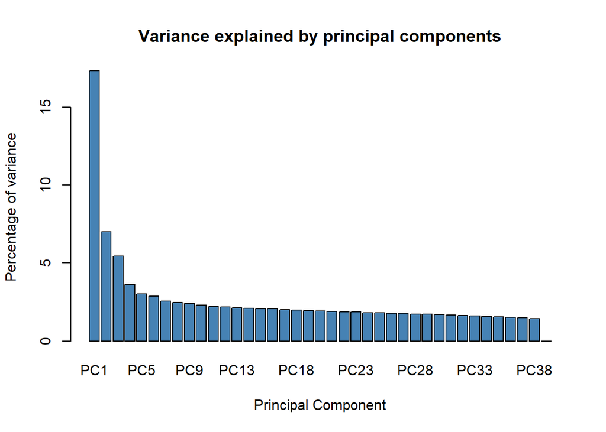

```r
var_explained <- summary(pca)$importance[2,] * 100
barplot(var_explained,
        main = "Variance explained by principal components",
        xlab = "Principal Component",
        ylab = "Percentage of variance",
        col = "steelblue")
```

## PCA plot function

```r
plot_pca <- function(pcaData, percentVar, combo,
                     color_by = "temperature", shape_by = "origin",
                     save = FALSE, save_dir = "results/sample_clustering/PCA") {
  x_pc <- combo[1]; y_pc <- combo[2]

  p <- ggplot(pcaData, aes_string(
    x = paste0("PC", x_pc),
    y = paste0("PC", y_pc),
    color = color_by,
    shape = shape_by
  )) +
    geom_point(size = 3) +
    xlab(paste0("PC", x_pc, ": ", percentVar[x_pc], "% variance")) +
    ylab(paste0("PC", y_pc, ": ", percentVar[y_pc], "% variance")) +
    ggtitle(paste0("PCA colored by ", color_by,
                   " (PC", x_pc, " vs PC", y_pc, ")")) +
    theme_minimal() +
    scale_color_manual(values = c(
      "12" = "blue", "15" = "green", "18" = "red",
      "Hybrid" = "purple", "South" = "orange", "West" = "darkgreen"
    )) +
    scale_shape_manual(values = c("Hybrid" = 16, "South" = 17, "West" = 18,
                                  "12" = 16, "15" = 17, "18" = 18))

  print(p)

  if (save) {
    ggsave(
      filename = file.path(save_dir,
        paste0("PCA_", color_by, "_PC", x_pc, "_vs_PC", y_pc, ".png")),
      plot = p, width = 8, height = 6, dpi = 300
    )
  }
}
```

## Generate PCA Plots

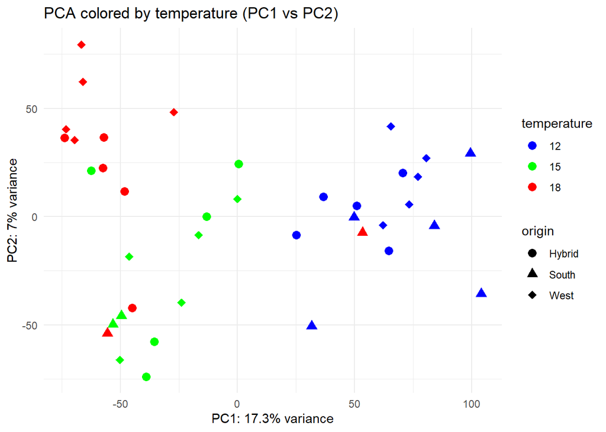

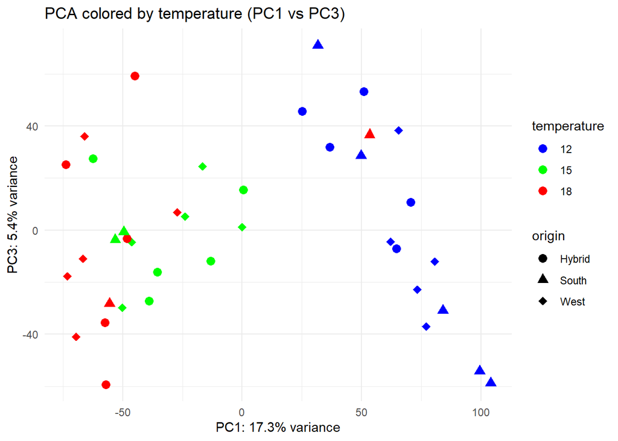

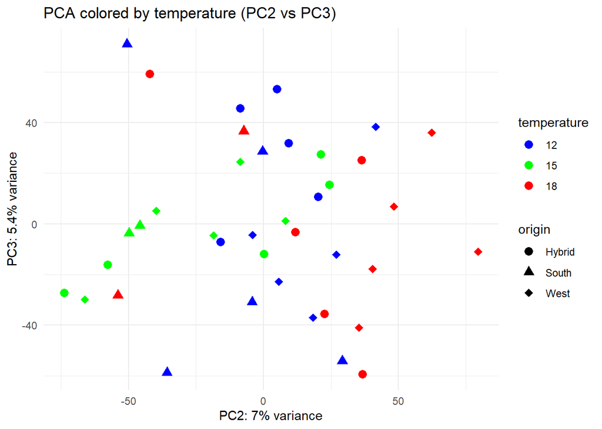

```r
pc_combos <- list(c(1,2), c(1,3), c(2,3))

# Temperature as color, origin as shape
for (combo in pc_combos) {
  plot_pca(pcaData, percentVar, combo, color_by = "temperature", shape_by = "origin", save = TRUE)
}
```

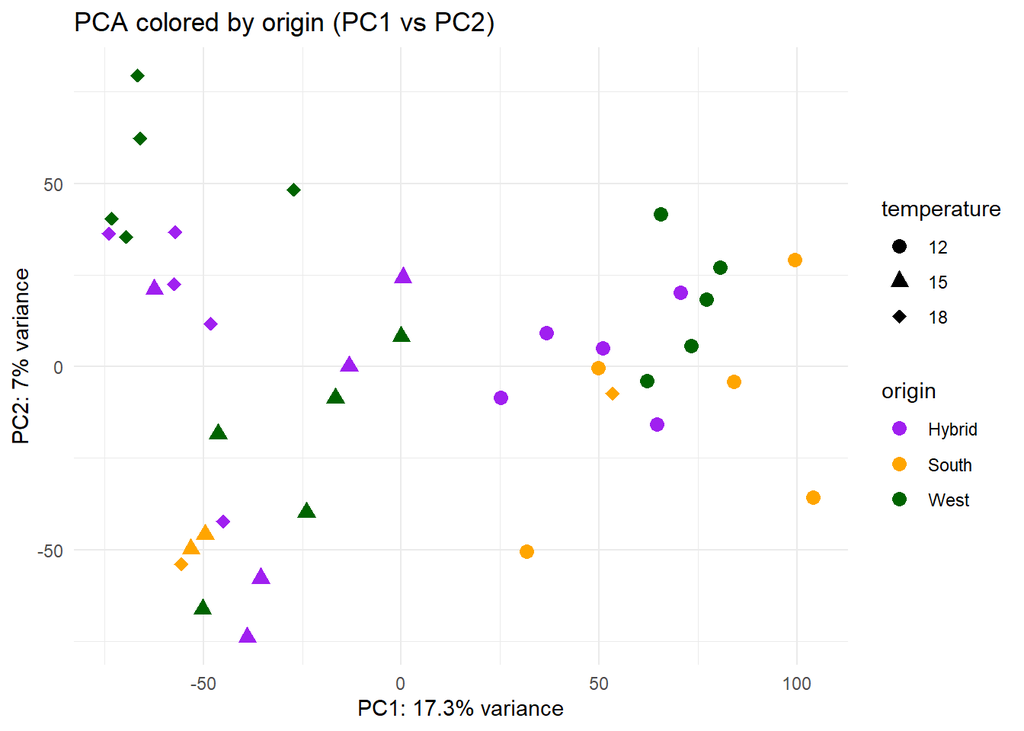

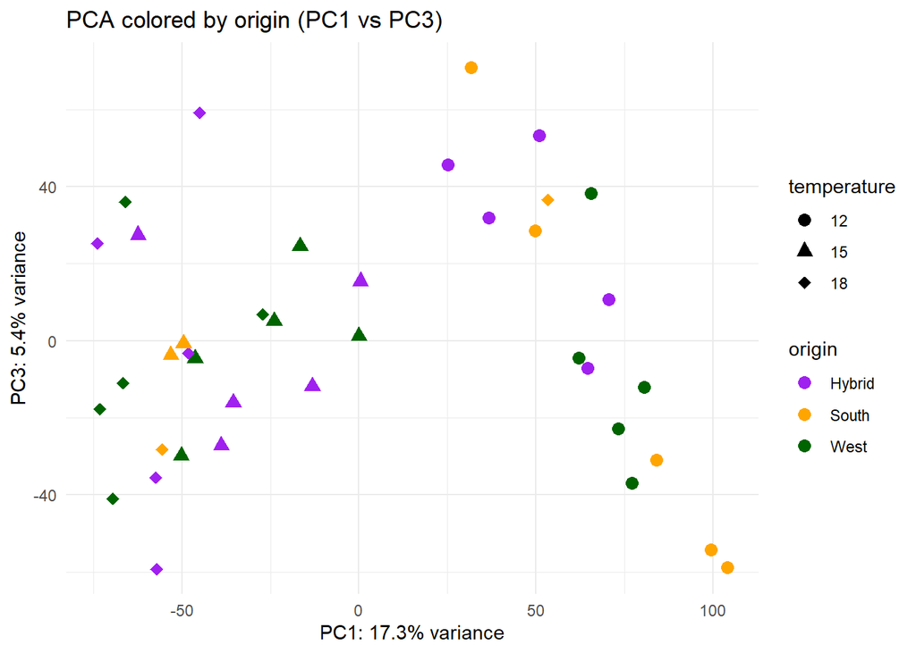

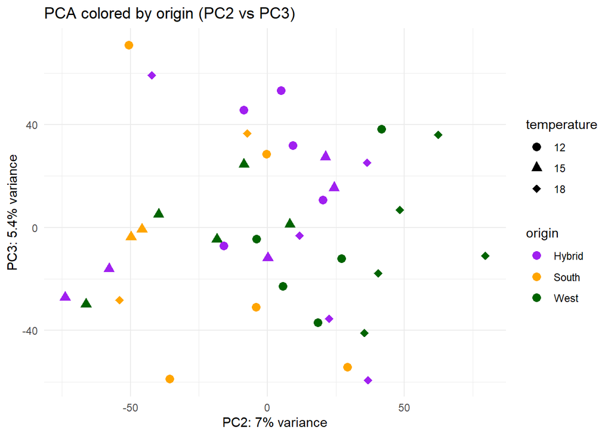

```r
# Origin as color, temperature as shape
for (combo in pc_combos) {
  plot_pca(pcaData, percentVar, combo, color_by = "origin", shape_by = "temperature", save = TRUE)
}
```

Principal Component Analysis revealed that temperature was the dominant driver of transcriptomic variation, with clear clustering along PC1 (17.3% of variance) and PC2 (7%). In contrast, no distinct clustering by population origin (West, Hybrid, South) was observed. Two South individuals exposed to 18°C did not cluster together: one grouped with the 12°C cluster and the other with the 15°C cluster. Likewise, one Hybrid individual at 18°C clustered with the 15°C group, while another Hybrid at 15°C clustered with the 18°C group. These atypical placements suggest that South individuals do not consistently activate distinct transcriptional programs under the 18°C treatment, and that Hybrids may inherit part of this response pattern. Overall, the PCA highlights temperature‑driven clustering with a few notable deviations, which will be further clarified in downstream differential expression analyses.

## Build dataset for correlation tests and plots

```r
## Build corData with PCA scores + morphometrics
pc_scores <- as.data.frame(pca$x)
pc_scores$Sample <- rownames(pc_scores)

corData <- sample_info %>%
  select(sample, origin, temperature, length, weight, condition_factor) %>%
  left_join(pc_scores, by = c("sample" = "Sample"))

# Preview merged data
knitr::kable(head(corData), caption = "PCA scores with morphometric variables")
```

PCA scores with morphometric variables

| sample | origin | temperature | length | weight | condition_factor | PC1 | PC2 | PC3 | PC4 | PC5 | PC6 | PC7 | PC8 | PC9 | PC10 | PC11 | PC12 | PC13 | PC14 | PC15 | PC16 | PC17 | PC18 | PC19 | PC20 | PC21 | PC22 | PC23 | PC24 | … |
| --- | --- | --- | --- | --- | --- | --- | --- | --- | --- | --- | --- | --- | --- | --- | --- | --- | --- | --- | --- | --- | --- | --- | --- | --- | --- | --- | --- | --- | --- | --- |
| 1040 | West | 18 | 10.6 | 0.032 | 2.6867817 | -65.9902552 | 62.363797 | 35.981789 | 1.865806 | -4.627923 | 38.2004874 | -3.115549 | 6.080143 | -16.051488 | 8.7838261 | -2.802285 | -16.33080 | -23.399078 | 26.01533 | 0.0440252 | 0.1850497 | -26.690212 | -7.295351 | -19.9520893 | 9.023108 | 3.293742 | 3.733752 | 6.440465 | 43.980141 | … |
| 1037 | West | 18 | 18.4 | 0.064 | 1.0273691 | -69.5747394 | 35.371760 | -40.934921 | 39.081764 | 12.356096 | -15.3894416 | 9.088009 | -39.562945 | 40.625672 | -0.3903847 | -23.600473 | -11.58728 | 15.899650 | -12.24668 | 4.6327752 | 44.9077378 | 18.182468 | 33.808963 | -21.5006105 | -5.612353 | -16.484011 | 47.408865 | -6.098505 | -9.355850 | … |
| 1036 | West | 18 | 14.6 | 0.041 | 1.3174231 | -66.6818134 | 79.493479 | -10.942716 | 8.152443 | 4.845507 | -5.0941916 | -13.702796 | -11.853431 | 35.246012 | 11.7878584 | 1.182386 | -18.66489 | 22.022666 | 10.51962 | -26.5793949 | -12.0176017 | 1.513228 | -13.944070 | -14.4159687 | 17.607275 | 18.738844 | -20.257092 | 31.356153 | 30.776786 | … |
| 1035 | West | 18 | 14.1 | 0.025 | 0.8918312 | -73.2064339 | 40.388314 | -17.740426 | 23.371381 | 14.412502 | 0.7238845 | 19.654610 | 10.787173 | 5.476667 | 28.0996002 | -9.078635 | -27.76614 | -3.557809 | -21.45282 | 11.5665319 | 1.6117449 | -5.792146 | -24.229619 | 33.9594478 | 7.227648 | 3.371758 | -26.873301 | -62.597490 | 13.689007 | … |
| 1033 | West | 18 | 17.9 | 0.035 | 0.6102516 | -27.1968171 | 48.318026 | 6.905558 | -12.175840 | -12.381027 | -9.4315473 | 45.503805 | -12.958577 | -25.863827 | -34.1545858 | -29.747861 | 10.67191 | -18.928318 | 18.90394 | 28.1445007 | 1.8314647 | 26.826906 | -35.206354 | -15.7201808 | 1.985634 | 8.531596 | 2.931261 | -34.490411 | -17.214285 | … |
| 1025 | West | 15 | 16.3 | 0.050 | 1.1545352 | -0.0291459 | 8.169113 | 1.171484 | -3.926189 | 24.069336 | -11.2242795 | -20.330441 | 26.902824 | -31.384018 | -37.6934304 | -21.233945 | 19.74146 | 8.855512 | 12.30494 | -26.8167221 | 1.8122438 | 42.910420 | -3.319077 | 0.8061511 | 13.709768 | 46.082514 | -3.818218 | 9.420098 | -3.857888 | … |

## Spearman Correlation Analysis: PC1 vs Morphometrics

```r
# Run Spearman correlations between PC1 scores and each trait
cor_results <- list(
  PC1_vs_Length = cor.test(corData$PC1, corData$length, method = "spearman"),
  PC1_vs_Weight = cor.test(corData$PC1, corData$weight, method = "spearman"),
  PC1_vs_CF     = cor.test(corData$PC1, corData$condition_factor, method = "spearman")
)

# Collect results into a tidy summary table
cor_table <- data.frame(
  Trait = c("Length", "Weight", "Condition Factor"),
  Rho   = c(cor_results$PC1_vs_Length$estimate,
            cor_results$PC1_vs_Weight$estimate,
            cor_results$PC1_vs_CF$estimate),
  Pval  = c(cor_results$PC1_vs_Length$p.value,
            cor_results$PC1_vs_Weight$p.value,
            cor_results$PC1_vs_CF$p.value)
)

# Display results
knitr::kable(cor_table, digits = 3,
             caption = "Spearman correlations between PC1 and morphometric traits")
```

Spearman correlations between PC1 and morphometric traits

| Trait | Rho | Pval |
| --- | --- | --- |
| Length | 0.422 | 0.007 |
| Weight | 0.504 | 0.001 |
| Condition Factor | -0.046 | 0.782 |

Spearman correlation tests confirmed that PC1 was significantly associated with both length (ρ = 0.42, p = 0.007) and weight (ρ = 0.50, p = 0.001), but not with condition factor (ρ ≈ 0, p = 0.78).

## Scatterplots of PC1 vs Morphometric Traits

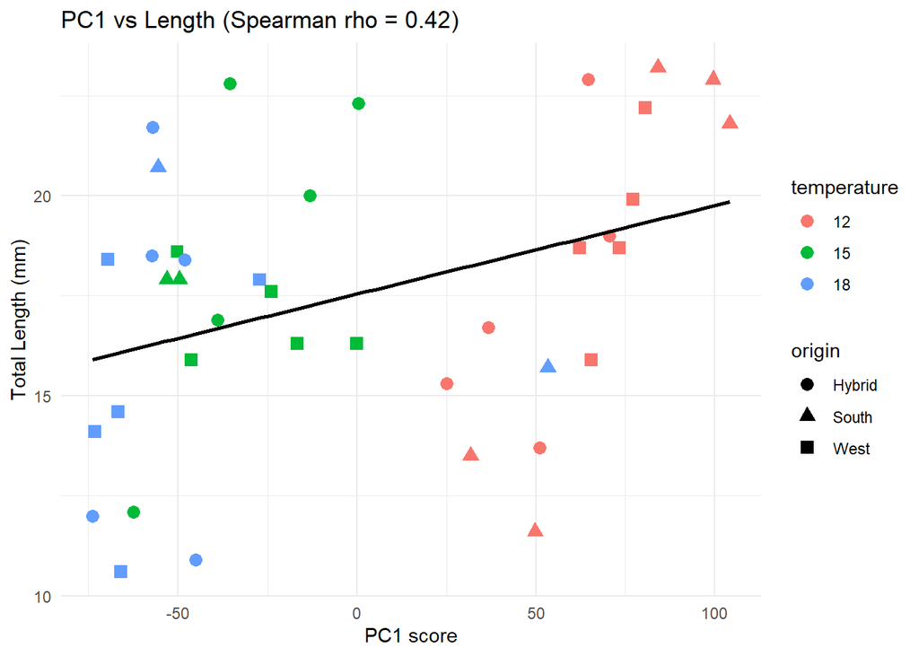

```r
# PC1 vs Length
ggplot(corData, aes(x = PC1, y = length,
                    color = temperature, shape = origin)) +
  geom_point(size = 3) +
  geom_smooth(method = "lm", se = FALSE, color = "black", aes(group = 1)) +
  labs(title = paste0("PC1 vs Length (Spearman rho = ",
                      round(cor_results$PC1_vs_Length$estimate, 2), ")"),
       x = "PC1 score", y = "Total Length (mm)") +
  theme_minimal()
```

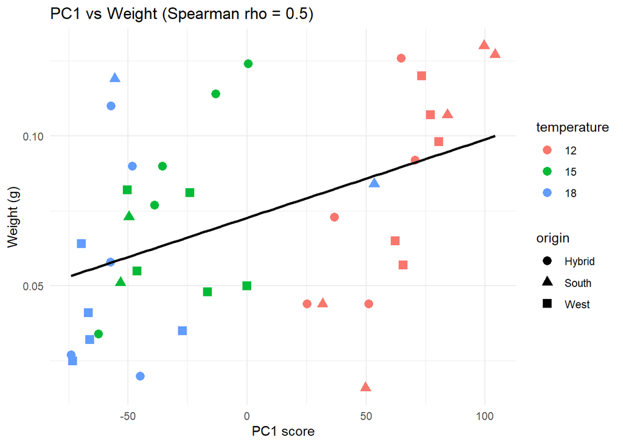

```r
# PC1 vs Weight
ggplot(corData, aes(x = PC1, y = weight,
                    color = temperature, shape = origin)) +
  geom_point(size = 3) +
  geom_smooth(method = "lm", se = FALSE, color = "black", aes(group = 1)) +
  labs(title = paste0("PC1 vs Weight (Spearman rho = ",
                      round(cor_results$PC1_vs_Weight$estimate, 2), ")"),
       x = "PC1 score", y = "Weight (g)") +
  theme_minimal()
```

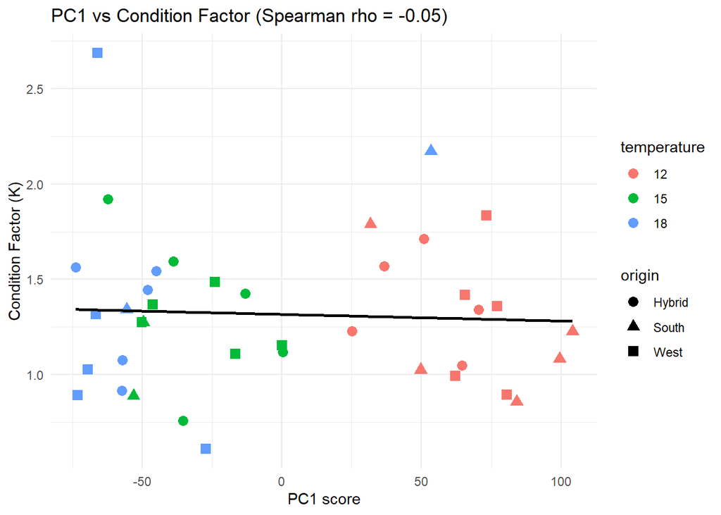

```r
# PC1 vs Condition Factor
ggplot(corData, aes(x = PC1, y = condition_factor,
                    color = temperature, shape = origin)) +
  geom_point(size = 3) +
  geom_smooth(method = "lm", se = FALSE, color = "black", aes(group = 1)) +
  labs(title = paste0("PC1 vs Condition Factor (Spearman rho = ",
                      round(cor_results$PC1_vs_CF$estimate, 2), ")"),
       x = "PC1 score", y = "Condition Factor (K)") +
  theme_minimal()
```

Scatterplots of PC1 against condition factor, length, and weight were overlaid with regression lines to visualize potential associations. The regression line for condition factor was flat, indicating that relative body condition (K) does not contribute to the transcriptomic variation captured by PC1. In contrast, PC1 showed upward slopes with both length and weight, consistent with the significant Spearman correlations, and suggesting that developmental stage contributes to the observed variation. This indicates that developmental stage, rather than nutritional status or energy reserves, explains the clustering pattern. Because length and weight are highly collinear, we included length as a covariate in downstream differential expression models to control for developmental stage effects. Length was chosen over weight because it provides a more stable and biologically interpretable measure of growth stage, whereas weight can fluctuate with short‑term physiological factors.

```r
normalizePath("../docs/chapter1_rnaseq/DE_reports")
```

```
## [1] "C:\\Users\\carlotam\\Documents\\PhD_docs\\corkwing_wrasse\\docs\\chapter1_rnaseq\\DE_reports"
```